# Two-Compartment PK/PD Model of R-Ibuprofen

### Setting up parameters

> To add our parameters,, we can simply create a `list` function that incorporates the parameters that we extracted from Lötsch et al.

```r
pk_pd_ibu_pain <- list(   # the parameters for the PD simulation for Pain ratings
  "KA" = 1.52,
  "V" = 5.45,
  "V2"= 5.2,
  "CL" = 4.64,
  "Q"= 4.1,
  "EFF"=100,
  "EC50"=24.4,
  "ke0"=1.1
)


pk_pd_ibu_ep <- list(   # the parameters for the PD simulation for Evoked potentials
  "KA" = 1.52,
  "V" = 5.45,
  "V2"= 5.2,
  "CL" = 4.64,
  "Q"= 4.1,
  "EFF"=100,
  "EC50"=8.71,
  "ke0"=0.27
)
```

### Setting Up a Regiment

> To set up our regiment we can use the command `new_regimen()` to provide dose amount(mg) and number of doses(n). - For multiple doses, we may also add a dosing interval `(interval=number)` or a times vector that has all the times that multiple doses will be administered.

> Our model will need one dose of 400mg S-Ibuprofen in one interval.

```r
reg_ibu <- new_regimen( # the drug regiment
  amt = 400,
  interval = 10,
  n = 1
)
```

### Setting Up the number of individuals

```r
n_ibu_trial<- 12 #number of individuals tested
```

## Simulating the data

> To simulate PKPD data, we will need to use the `sim()` function, which will simulate the model function we set up with `new_ode_model`. The data will then be saved into a `data.frame`, which we can then graph.

> When setting up the `sim()` function, we will need to add all of our previous metrics and a few additional metrics to help us generate better data.

> For this model, we will only need to define two necessary metrics:
> 1. The time points that data has been recorded. This can be done using the `t_obs =` command, where the time points can be entered through a vector.
>    - We have extracted the times of observations from Lötsch et al. *p.388*.
> 2. The Omega Matrix or Variability between the parameters based on the number of individuals. It could be written as either a vector, or we can specify the variability of a parameter by using `cv_to_omega(list(` and have a parameter = SD between individual parameters.
>    - Variability is optional. However, it is necessary to add randomness to simulations.
>    - Since Lötsch et al. do not provide us with a variability matrix SD between the parameters, we have instead chosen to run the parameters with very low SDs as they do not have high SDs with our PK and PD models.

```r
pkpdsimvalues_ibu <- sim_ode(
  ode = pkpdmodel_ibuprofen_pkdata,
  n_ind = n_ibu_trial,
  omega = cv_to_omega(
    par_cv = list(CL = 0.1, V = 0.1, V2 =0.125, Q = 0.2, ke0 = 0.05)), # the omega matrix is the subject variability for the parameters
  parameters = pk_pd_ibu_pain,
  regimen = reg_ibu ,
  t_obs = c(0, 0.167,.33, .5, .75, 1, 1.5, 2, 2.5, 4, 5, 6, 8, 10) #timepoints of the observation
)
```

```
## No parameter list provided as argument, assumed order for `omega_matrix`: CL, V, V2, Q, ke0
```

## Plotting all compartment results

> We can now plot all our compartments through `ggpolt`:

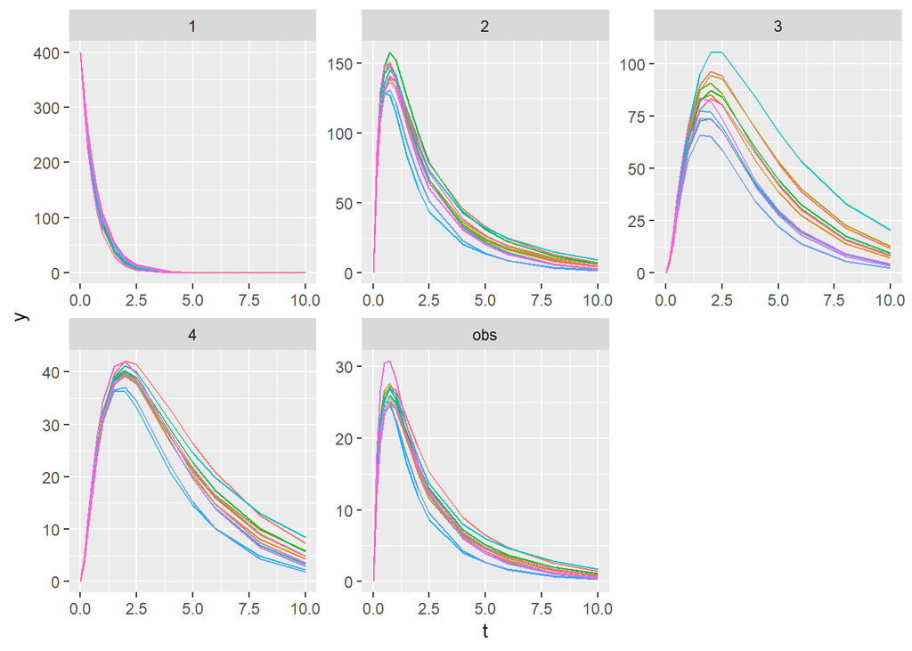

> Note that the axes are unlabeled. This is due to compartment 4 and the observation compartment not being a dose/time graph.

> This graph represents the dose change in the first three compartments, the concentration/time in the observation compartment, and the effect/time in *compartment 4*.

## Plotting the PK data

> We can filter our data through already established `sim()` by adding `only_obs = TRUE`.

> This will only generate the data for the observation compartment, the central compartment/blood plasma.

```r
pkpdsimvalues_ibu_pkobs <- sim_ode(
  ode = pkpdmodel_ibuprofen_pkdata,
  n_ind = n_ibu_trial,
  omega = cv_to_omega(
    par_cv = list(CL = 0.1, V = 0.1, V2 =0.125, Q = 0.2, ke0 = 0.05)), # the omega matrix is the subject variability for the parameters
  parameters = pk_pd_ibu_pain,
  regimen = reg_ibu ,
  t_obs = c(0, 0.167,.33, .5, .75, 1, 1.5, 2, 2.5, 4, 5, 6, 8, 10), #timepoints of the observation
  only_obs = T
)
```

```
## No parameter list provided as argument, assumed order for `omega_matrix`: CL, V, V2, Q, ke0
```

>Let us now plot the PK results:

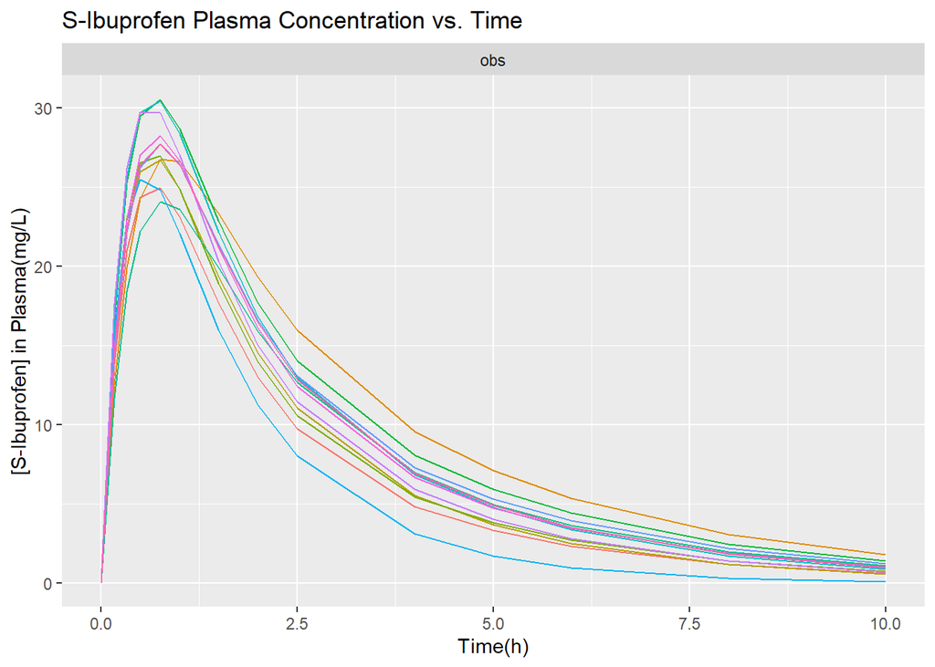

### PK data analysis

> In addition to the plot, we can use the observation data to measure the *Cmax*, *tmax* and *AUC* for the PK curve to help us compare with the data from from Lötsch et al.

```r
mean_ibu_pkobs_per_time <- pkpdsimvalues_ibu_pkobs %>% group_by(t) %>% summarise(sdev=sd(y), y=mean(y))
Cmax <- max(mean_ibu_pkobs_per_time$y)
sdev_cmax <-mean_ibu_pkobs_per_time$sdev[which.max(mean_ibu_pkobs_per_time$y)]
tmax <- mean_ibu_pkobs_per_time$t[which.max(mean_ibu_pkobs_per_time$y)]
mean_ibu_pkobs_per_conc <- pkpdsimvalues_ibu_pkobs %>% group_by(y) %>% summarise(sdev=sd(t))


#for the AUC we can use a for loop to summarize the AUC for each timepoint using a trapezoidal calculation
mean_ibu_pkobs_per_time$AUC <- 0
auc <- 0

for (i in 2:14) {
  t1 <- mean_ibu_pkobs_per_time[i-1, "t"]
  t2 <- mean_ibu_pkobs_per_time[i, "t"]
  y1 <- mean_ibu_pkobs_per_time[i-1, "y"]
  y2 <- mean_ibu_pkobs_per_time[i, "y"]

  auc <- auc + ((y2 + y1) / 2) * (t2 - t1)
  mean_ibu_pkobs_per_time$AUC[i] <- auc
}

print(Cmax)
```

```
## [1] 27.40561
```

```r
print(sdev_cmax)
```

```
## [1] 2.131484
```

```r
print(tmax)
```

```
## [1] 0.75
```

```r
print(auc)
```

```
##          y
## 1 80.04034
```

> We can now set up the PK statistical measurement data alongside the results from Lötsch et al.
> - SD for *tmax* and *AUC* are not included as we could not find the right code for them.
>   - We can note that the *tmax* SD may be relatively low as the majority of the high concentration values lie around 0.75, with a few occasionally being 0.5.
>   - For *AUC*, we believe that the standard range that resulted from multiple simulations has a range from about 76 to 90, giving it a standard deviation that is lower than that of Lötsch et al.

```r
#let's set up a table to compare the two

Lötsch_et_al. <- c(20, 2.9, 1, .57, 67.5, 14.9)
PK_model<- c(Cmax, sdev_cmax, tmax, 0, auc, 0)
PKstats <- rbind (Lötsch_et_al., PK_model)
colnames(PKstats) <- c("Cmax(mg/L)", "SD_Cmax", "tmax(h)", "SD_tmax", "AUC(mg h/L)", "SD_AUC")
print(PKstats)
```

```
##               Cmax(mg/L) SD_Cmax  tmax(h) SD_tmax AUC(mg h/L) SD_AUC
## Lötsch_et_al. 20         2.9      1       0.57    67.5        14.9
## PK_model      27.40561   2.131484 0.75    0       80.04034    0
```

## Plotting the PD data

> For PD data we have to slightly tweak the observation compartment in our original `new_ode_model` function to set the fourth compartment *(cmt = 4)* as our observation compartment and remove any scaling *(scale = 1)*.

```r
pkpdmodel_ibuprofen_pddata <- new_ode_model(code = "
    dAdt[1] = -KA * A[1]
    dAdt[2] = KA * A[1] -(CL/V) * A[2] + (Q/V2)*A[3] - Q/V*A[2]
    dAdt[3] = -(Q/V2)*A[3] + (Q/V)*A[2]
    conc= A[2]/V
    dAdt[4] = ke0 * (EFF*conc)/(conc+EC50) - ke0*A[4]
  ",
                                            state_init = "A[4] = 0;",

                                            obs = list(cmt = 4, scale = 1),

                                            dose = list(cmt = 1, bioav = 1)
)
```

> To setup our `sim()`function for PD, we can just change the `ode=` to the PD model:

```r
pkpdsimvalues_ibu_pdobs_pain <- sim_ode(
  ode = pkpdmodel_ibuprofen_pddata,
  n_ind = n_ibu_trial,
  omega = cv_to_omega(
    par_cv = list(CL = 0.1, V = 0.1, V2 =0.125, Q = 0.2, ke0 = 0.05)), # the omega matrix is the subject variability for the parameters
  parameters = pk_pd_ibu_pain,
  regimen = reg_ibu ,
  t_obs = c(0, 0.167,.33, .5, .75, 1, 1.5, 2, 2.5, 4, 5, 6, 8, 10), #timepoints of the observation
  only_obs = T
)
```

```
## No parameter list provided as argument, assumed order for `omega_matrix`: CL, V, V2, Q, ke0
```

> Let’s plot the curve for Pain Ratings:

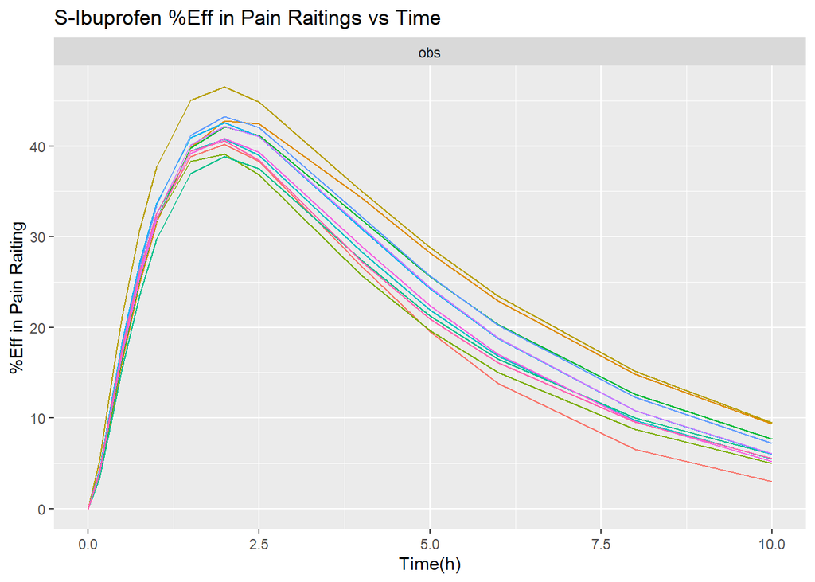

> By changing the parameters to *pk_pd_ibu_ep* we can simulate the PD data for Evoked Potentials.

```r
pkpdsimvalues_ibu_pdobs_ep <- sim_ode(
  ode = pkpdmodel_ibuprofen_pddata,
  n_ind = n_ibu_trial,
  omega = cv_to_omega(
    par_cv = list(CL = 0.1, V = 0.1, V2 =0.125, Q = 0.2, ke0 = 0.05)), # the omega matrix is the subject variability for the parameters
  parameters = pk_pd_ibu_ep,
  regimen = reg_ibu ,
  t_obs = c(0, 0.167,.33, .5, .75, 1, 1.5, 2, 2.5, 4, 5, 6, 8, 10), #timepoints of the observation
  only_obs = T
)
```

```
## No parameter list provided as argument, assumed order for `omega_matrix`: CL, V, V2, Q, ke0
```

> Let’s plot the PD curve for Evoked Potentials.

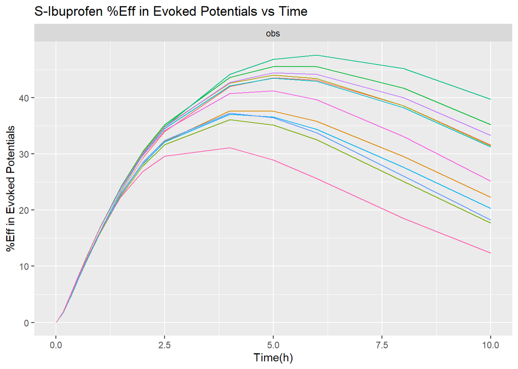

### PD data analysis

> We can set up functions to calculate *Emax* and *tmax_eff* for the PD data like we did with the PK data.

> AUC will not be necessary since Lötsch et al. did not provide much statistical analysis for the PD data.

> We can measure the maximum efficacy and maximum time of efficacy for Pain Ratings to see how each of the models changes over time.

```r
mean_ibu_pdobs_per_time_pain <- pkpdsimvalues_ibu_pdobs_pain %>% group_by(t) %>% summarise(sdev=sd(y), y=mean(y))
Emax_pain <- max(mean_ibu_pdobs_per_time_pain$y)
sdev_Emax_pain <-mean_ibu_pdobs_per_time_pain$sdev[which.max(mean_ibu_pdobs_per_time_pain$y)]
tmax_eff_pain <- mean_ibu_pdobs_per_time_pain$t[which.max(mean_ibu_pdobs_per_time_pain$y)]

print(Emax_pain)
```

```
## [1] 41.64066
```

```r
print(sdev_Emax_pain)
```

```
## [1] 2.09714
```

```r
print(tmax_eff_pain)
```

```
## [1] 2
```

> Let’s do the same for Evoked Potentials:

```r
mean_ibu_pdobs_per_time_ep <- pkpdsimvalues_ibu_pdobs_ep %>% group_by(t) %>% summarise(sdev=sd(y), y=mean(y))
Emax_ep <- max(mean_ibu_pdobs_per_time_ep$y)
sdev_Emax_ep <-mean_ibu_pdobs_per_time_ep$sdev[which.max(mean_ibu_pdobs_per_time_ep$y)]
tmax_eff_ep <- mean_ibu_pdobs_per_time_ep$t[which.max(mean_ibu_pdobs_per_time_ep$y)]

print(Emax_ep)
```

```
## [1] 40.31107
```

```r
print(sdev_Emax_ep)
```

```
## [1] 5.352164
```

```r
print(tmax_eff_ep)
```

```
## [1] 5
```

# 4. Results & Interpretation

## Comparing PK data with Lötsch et al.

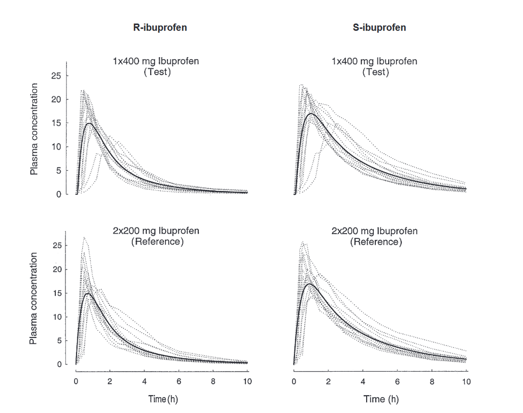

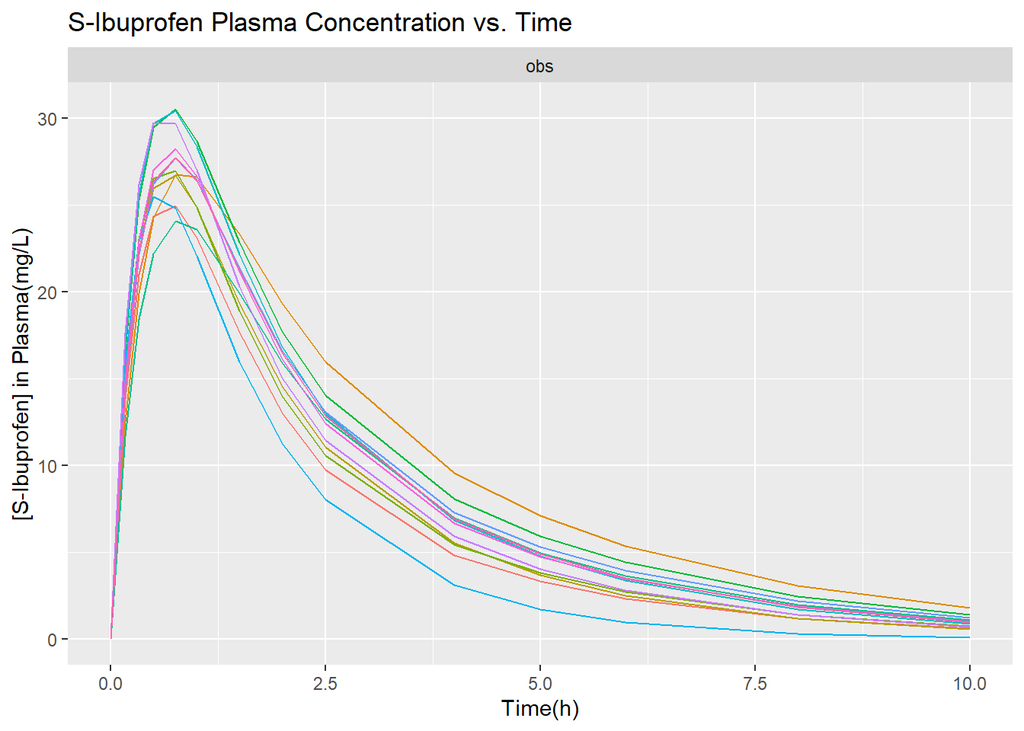

```r
Lötsch_et_al. <- c(20, 2.9, 1, .57, 67.5, 14.9)
PK_model<- c(Cmax, sdev_cmax, tmax, 0, auc, 0)
PKstats <- rbind (Lötsch_et_al., PK_model)
colnames(PKstats) <- c("Cmax(mg/L)", "SD_Cmax", "tmax(h)", "SD_tmax", "AUC(mg h/L)", "SD_AUC")
print(PKstats)
```

```
##               Cmax(mg/L) SD_Cmax  tmax(h) SD_tmax AUC(mg h/L) SD_AUC
## Lötsch_et_al. 20         2.9      1       0.57    67.5        14.9
## PK_model      27.40561   2.131484 0.75    0       80.04034    0
```

> Both graphs maintain a similar curve shape.

## Comparing PD data with Lötsch et al.

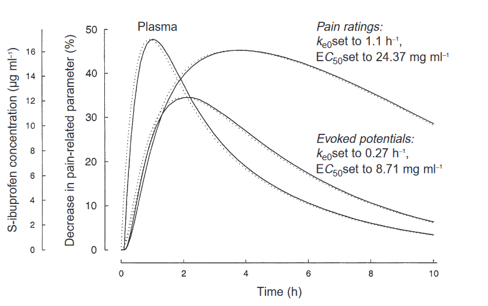

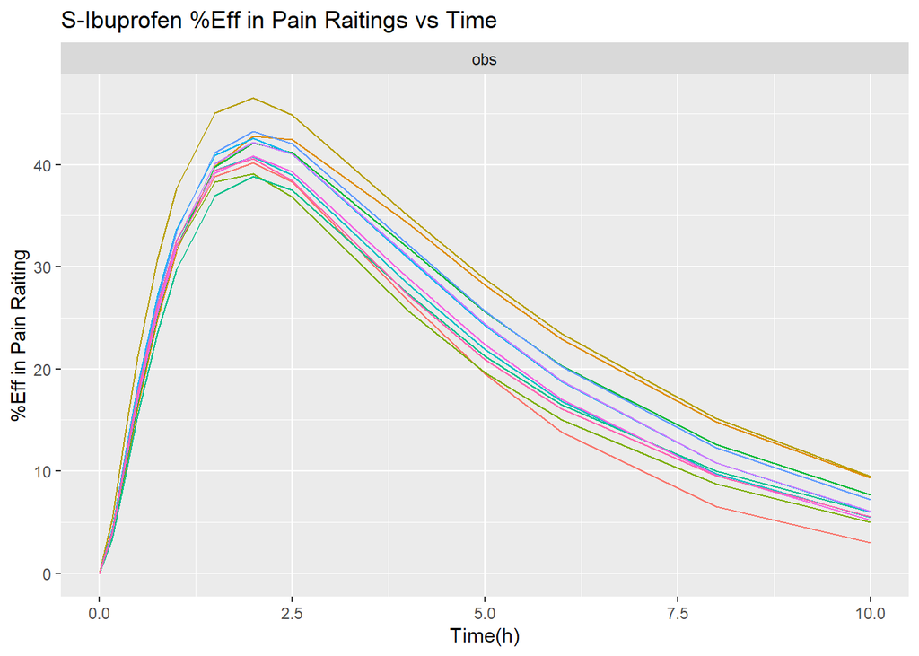

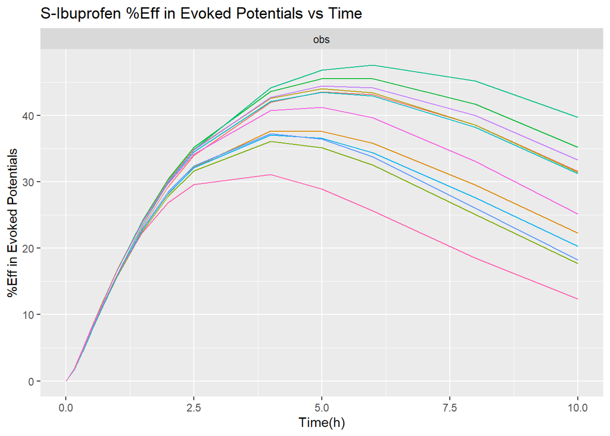

> As mentioned previously, there is no statistical analysis for the PD aspect of their data, and therefore, there can be no additional comments.

# References

- Lötsch J, Muth-Selbach U, Tegeder I, Brune K, Geisslinger G. Simultaneous fitting of R- and S-ibuprofen plasma concentrations after oral administration of the racemate. Br J Clin Pharmacol. 2001 Oct;52(4):387-98. doi: 10.1046/j.1365-2125.2001.01451.x. PMID: 11678782; PMCID: PMC2014594.
- Keizer R, Hughes J, Tong D, Woo K, Brooks J (2024). PKPDsim: Tools for Performing Pharmacokinetic-Pharmacodynamic Simulations. R package version 1.3.0, https://insightrx.github.io/PKPDsim/, https://github.com/InsightRX/PKPDsim. Zou H, Banerjee P, Leung SSY, Yan X. Application of Pharmacokinetic-Pharmacodynamic Modeling in Drug Delivery: Development and Challenges. Front Pharmacol. 2020 Jul 3;11:997. doi: 10.3389/fphar.2020.00997. PMID: 32719604; PMCID: PMC7348046.
- Stuart-Harris R, Joel SP, McDonald P, Currow D, Slevin ML. The pharmacokinetics of morphine and morphine glucuronide metabolites after subcutaneous bolus injection and subcutaneous infusion of morphine. Br J Clin Pharmacol. 2000 Mar;49(3):207-14. doi: 10.1046/j.1365-2125.2000.00141.x. PMID: 10718775; PMCID: PMC2014910.
- Grogan S, Preuss CV. Pharmacokinetics. [Updated 2023 Jul 30]. In: StatPearls [Internet]. Treasure Island (FL): StatPearls Publishing; 2024 Jan-. Available from: https://www.ncbi.nlm.nih.gov/books/NBK557744/
- https://mrgsolve.org/